# Showing number of rows per Apartment & House

```
subtype
house                   20096
villa                    2522
apartment block          1213
mixed use building        970
exceptional property      566
mansion                   409
town house                327
bungalow                  285
country cottage           211
farmhouse                 152
chalet                     72
castle                     35
other property             21
manor house                19
pavilion                    1
Name: count, dtype: int64
subtype
apartment       13492
duplex           1119
ground floor     1052
penthouse         733
flat studio       300
service flat      251
loft              174
triplex            95
kot                81
Name: count, dtype: int64
```

# Outliers per subtype for apartment and house in numerical columns

- Apartment
  - Suggests outliers number bedrooms appartment > 5 in apt, duplex, penthouse, groundfloor, triplex, kot
  - Surface > 10k m2 in ground floor 2 outliers
  - Bunch of outliers identified more than 1 million EUR
  - Bunch of outliers in price per m2
- House
  - Outliers found in bedroom numbers more than 10 which can be explained in some categories such as appartment block
  - Extreme outliers Surface in house & farmhouse
  - Bunch of outlier more than 2 million EUR
  - Bunch of outliers more than 10K per m2

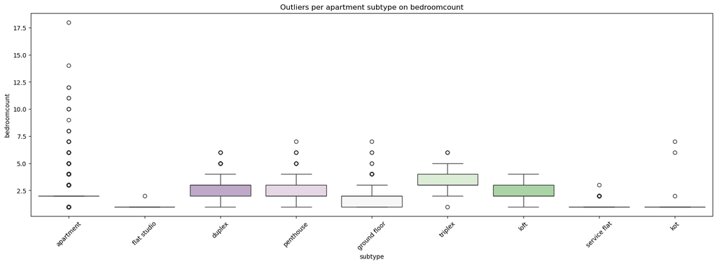

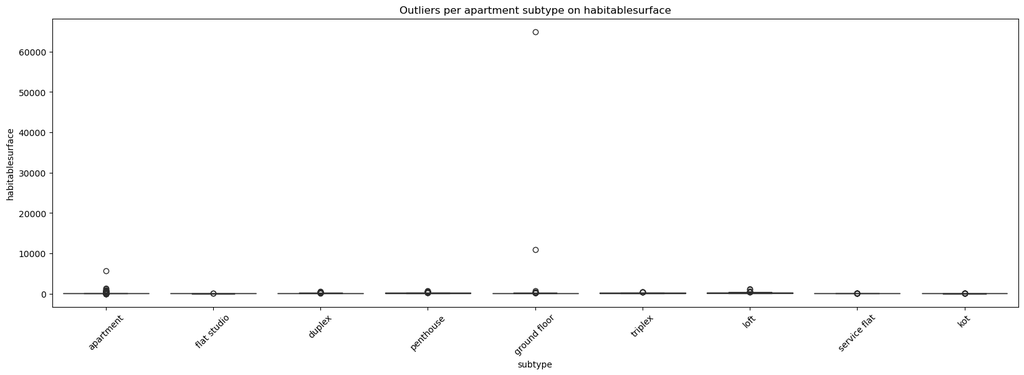

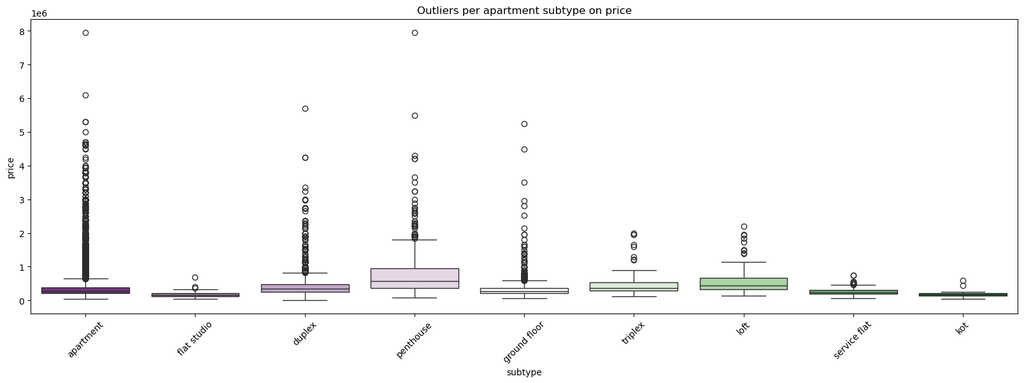

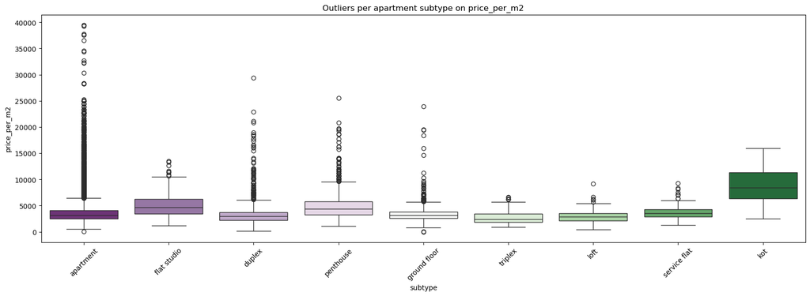

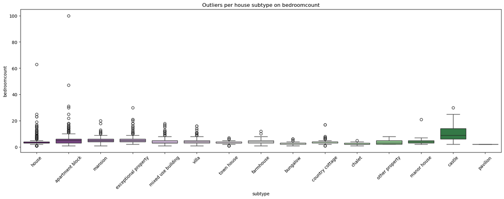

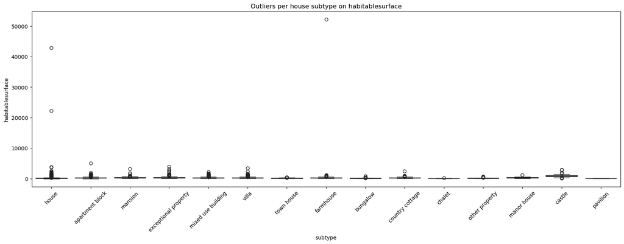

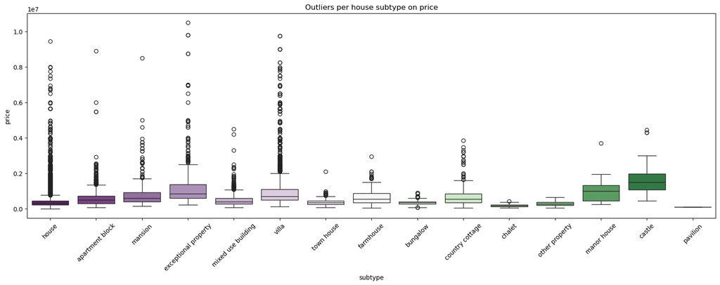

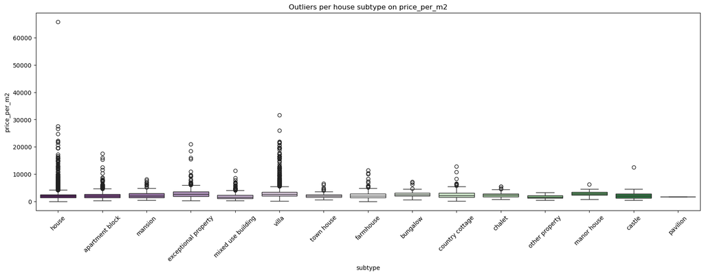

# Statistical outliers identification on subtype and regions

- Focus on identifying the number of outliers
- Outliers as 2X the diff 75% 25% quantiles
  - Bedrooms: appartmentblock, house subtypes top Wallonia 67, 45 number of outliers
  - Surface: house and villa subtypes with top Flanders 342, 347 number of outliers
  - Price: house, apartment, villa with top Flanders 370, 490, 525 number of outliers
  - Price/m2: apartment, house, villa with top Flanders 1072, 115, 135 number of outliers

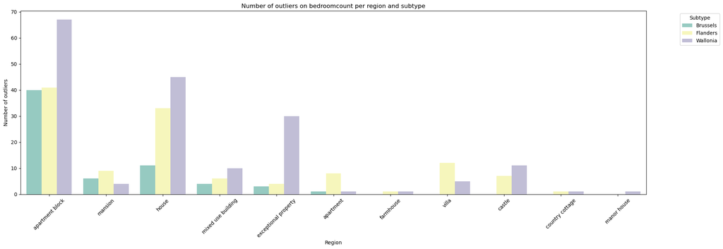

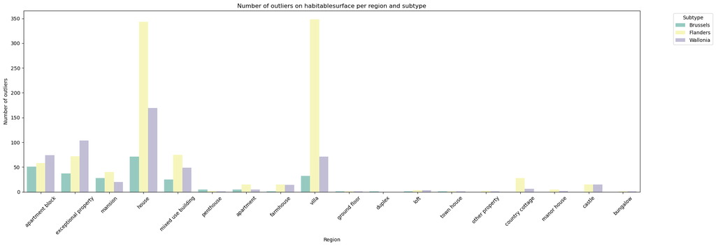

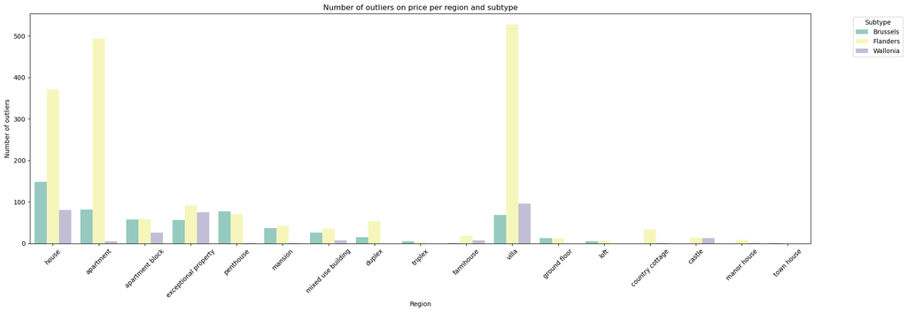

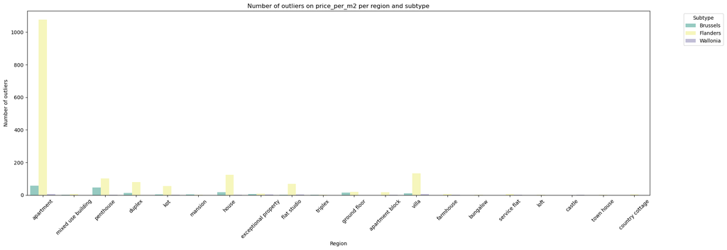

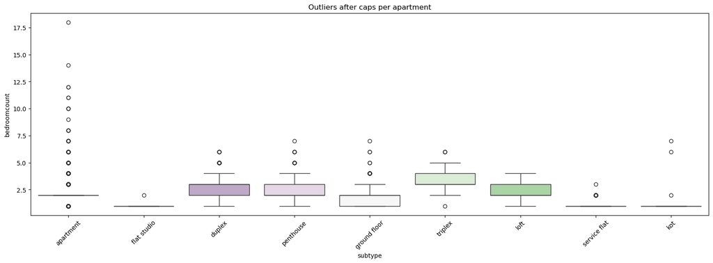

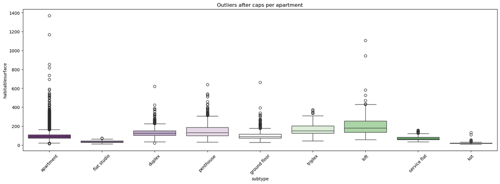

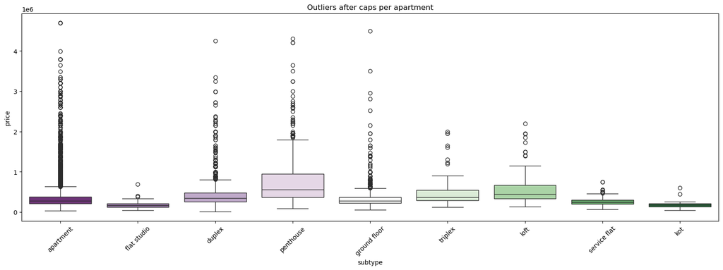

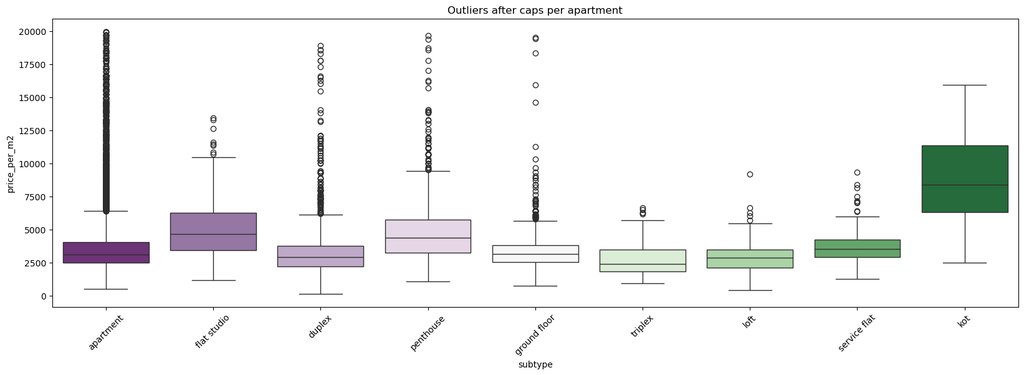

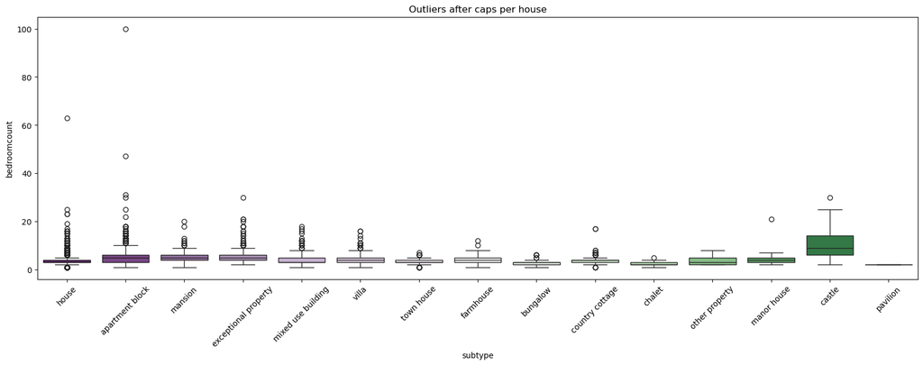

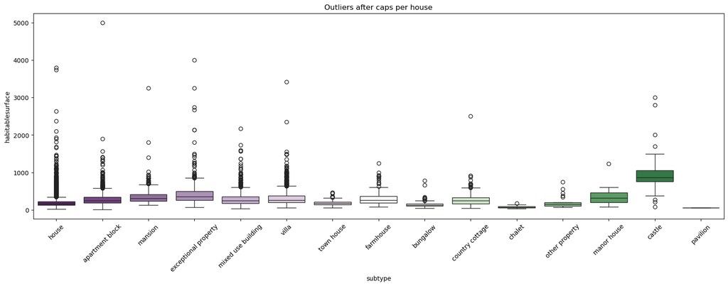

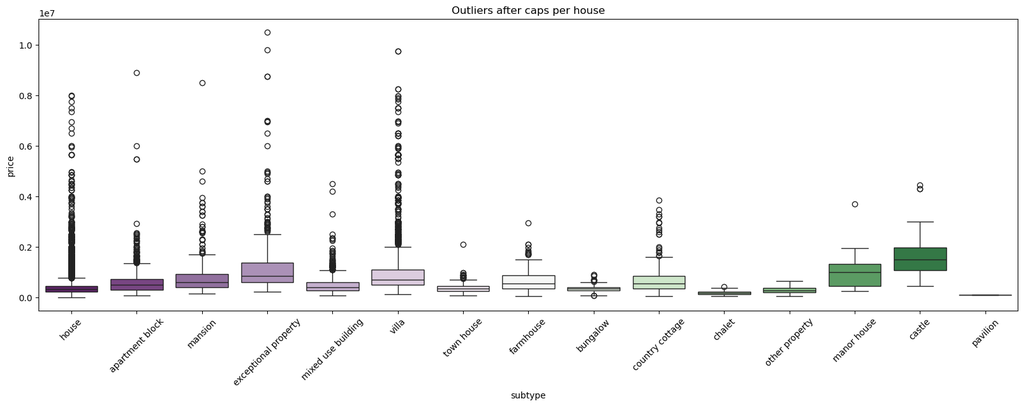

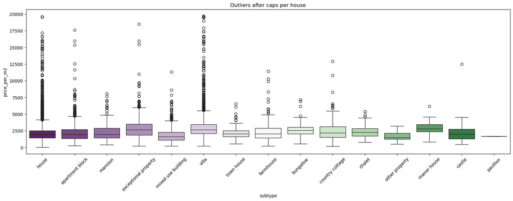

# KDE plot to see the distribution of various non-numerical versus p/m2

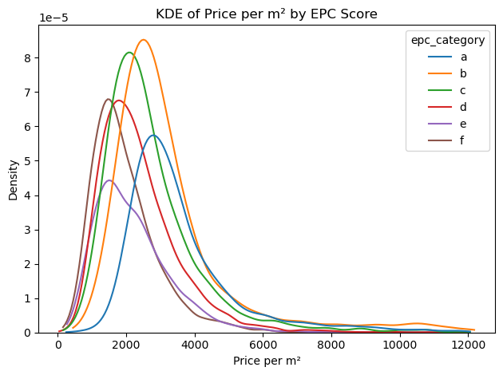

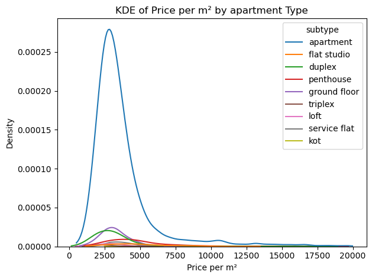

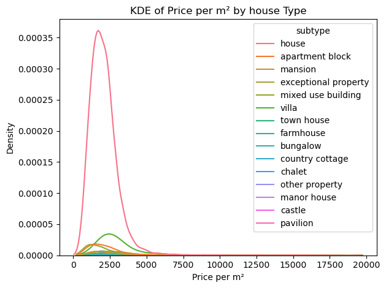

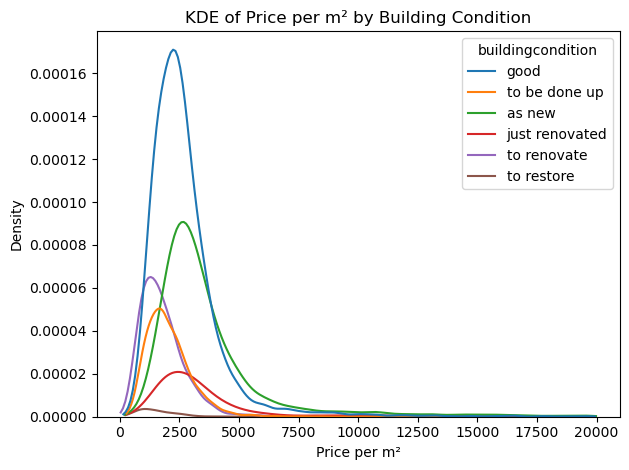

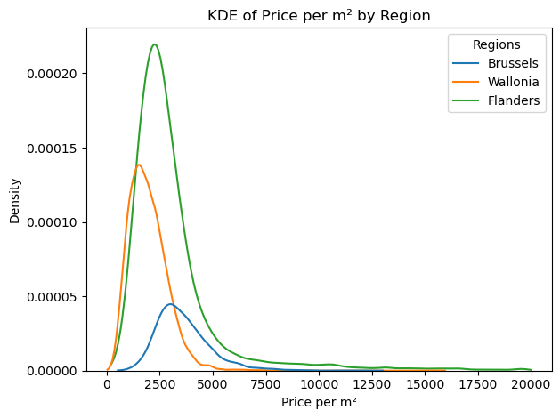